# LBRAI2219 - Modélisation des systèmes biologiques

### 4.2.4 Évolution de la quantité d’eau transpirée

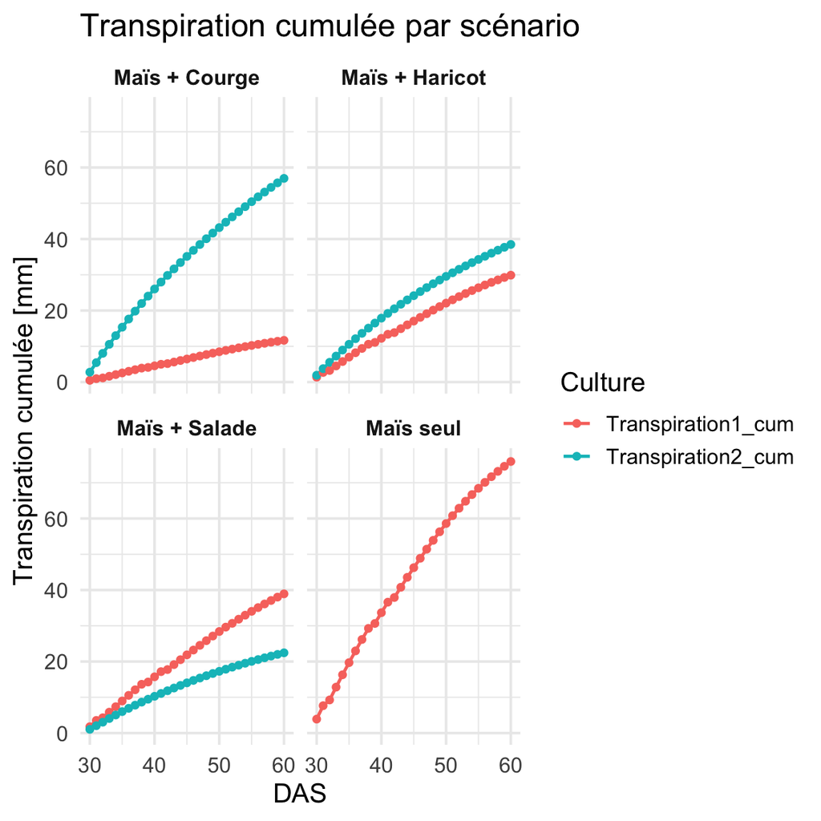

```r
# 1) Préparer chaque scénario avec deux colonnes Transpiration1_cum et Transpiration2_cum

#   Maïs seul : une seule culture → Transpiration2_cum = NA
df_mais_seul <- resultat_mais %>%
  mutate(
    Transpiration1_cum = cumsum(Transpiration),
    Transpiration2_cum = NA_real_,
    Scenario = "Maïs seul"
  ) %>%
  dplyr::select(Scenario, Jour, Transpiration1_cum, Transpiration2_cum)

#   Maïs + Haricot
df_mais_haricot <- resultats_mais_haricot %>%
  mutate(
    Transpiration1_cum = cumsum(Transpiration1),
    Transpiration2_cum = cumsum(Transpiration2),
    Scenario = "Maïs + Haricot"
  ) %>%
  dplyr::select(Scenario, Jour, Transpiration1_cum, Transpiration2_cum)

#   Maïs + Courge
df_mais_courge <- resultats_mais_courge %>%
  mutate(
    Transpiration1_cum = cumsum(Transpiration1),
    Transpiration2_cum = cumsum(Transpiration2),
    Scenario = "Maïs + Courge"
  ) %>%
  dplyr::select(Scenario, Jour, Transpiration1_cum, Transpiration2_cum)

#   Maïs + Salade
df_mais_salade <- resultats_mais_salade %>%
  mutate(
    Transpiration1_cum = cumsum(Transpiration1),
    Transpiration2_cum = cumsum(Transpiration2),
    Scenario = "Maïs + Salade"
  ) %>%
  dplyr::select(Scenario, Jour, Transpiration1_cum, Transpiration2_cum)

# 2) Concaténer et passer en format long, en supprimant les NA
df_transpi_all <- bind_rows(
  df_mais_seul,
  df_mais_haricot,
  df_mais_courge,
  df_mais_salade
) %>%
  pivot_longer(
    cols           = c(Transpiration1_cum, Transpiration2_cum),
    names_to       = "Culture",
    values_to      = "Transpiration_cum",
    values_drop_na = TRUE
  )

# 3) Tracé en facettes
ggplot(df_transpi_all, aes(x = Jour, y = Transpiration_cum, color = Culture)) +
  geom_line(size = 0.8) +
  geom_point(size = 1.5) +
  facet_wrap(~ Scenario, ncol = 2) +
  labs(
    title = "Transpiration cumulée par scénario",
    x     = "DAS",
    y     = "Transpiration cumulée [mm]",
    color = "Culture"
  ) +
  theme_minimal(base_size = 14) +
  theme(strip.text = element_text(face = "bold"))
```

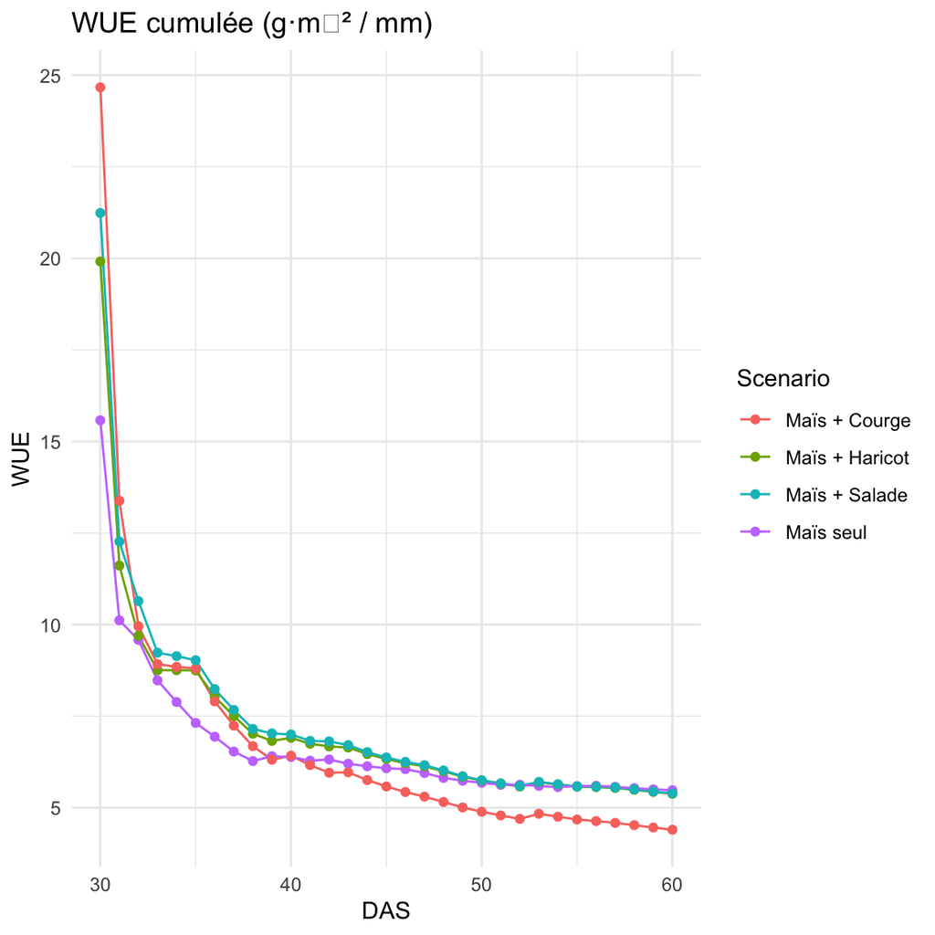

```r
# 1) Préparer WUE (Water Use Efficiency) cumulée pour chaque scénario
make_wue_df <- function(df, scenario, is_duo=FALSE) {
  if (!is_duo) {
    df2 <- df %>%
      mutate(
        Biomasse_cum = Biomasse_cum,
        Transp_cum   = cumsum(Transpiration)
      ) %>%
      dplyr::select(Jour, Biomasse_cum, Transp_cum) %>%
      mutate(Scenario = scenario)
  } else {
    df2 <- df %>%
      mutate(
        Biomasse_cum = Biomasse_cum1 + Biomasse_cum2,
        Transp_cum   = cumsum(Transpiration1) + cumsum(Transpiration2)
      ) %>%
      dplyr::select(Jour, Biomasse_cum, Transp_cum) %>%
      mutate(Scenario = scenario)
  }
  df2 %>%
    mutate(WUE = Biomasse_cum / Transp_cum)
}

wue_all <- bind_rows(
  make_wue_df(resultat_mais,               "Maïs seul",      FALSE),
  make_wue_df(resultats_mais_haricot,      "Maïs + Haricot", TRUE),
  make_wue_df(resultats_mais_courge,       "Maïs + Courge",  TRUE),
  make_wue_df(resultats_mais_salade,       "Maïs + Salade",  TRUE)
)

# a) WUE au cours du temps
ggplot(wue_all, aes(x = Jour, y = WUE, color = Scenario)) +
  geom_line() + geom_point() +
  labs(title="WUE cumulée (g·m⁻² / mm)", x="DAS", y="WUE") +
  theme_minimal()
```

```r
# b) table des valeurs de WUE à J60
wue_J60 <- wue_all %>%
  filter(Jour == 60) %>%
  dplyr::select(Scenario, WUE) %>%
  arrange(desc(WUE))

knitr::kable(
  wue_J60,
  col.names = c("Scénario", "WUE à J60 (g·m2/mm)"),
  caption   = "Tableau : Water Use Efficiency cumulée au jour 60"
)
```

Tableau : Water Use Efficiency cumulée au jour 60

| Scénario | WUE à J60 (g·m2/mm) |
| --- | --- |
| Maïs seul | 5.480513 |
| Maïs + Salade | 5.392999 |
| Maïs + Haricot | 5.381363 |
| Maïs + Courge | 4.400653 |

Le Water Use Efficiency (WUE) est défini comme le rapport entre la biomasse cumulée produite et l’eau transpirée : $\mathrm{WUE} = \frac{\sum B}{T}$ (Rouphael and Colla 2005)

On distingue deux phases dans l’évolution du WUE en fonction du DAS :

1. **Phase initiale (30–35 DAS)**  
   Toutes les courbes démarrent à des valeurs élevées (jusqu’à ~25 g·m⁻²/mm) et chutent rapidement, car la biomasse augmente rapidement alors que l’extraction d’eau reste faible lors des premiers jours de simulation.
2. **Stabilisation progressive**  
   Après environ 35 jours, la WUE tend vers un plateau situé entre 4,5 et 6 g·m⁻²/mm, reflet d’un équilibre entre accroissement de la biomasse et hausse de la transpiration quotidienne. Ceci est du au faible ralentissement de la production de biomasse et à la constante augmentation de la transpiration quotdienne du à cette production de biomasse et aux conditions de températures.

La monoculture (Maïs seul) obtient la WUE la plus élevée (5,48) grâce à l’absence de concurrence : toute l’eau consommée est valorisée en biomasse de maïs, l’Interculture avec salade (5,39) et avec haricot (5,38) présentent une WUE très proche de la monoculture, signe que ces associations préservent assez bien l’efficacité hydrique du système, alors que l’interculture avec courge chute nettement (4,40), la courge mobilisant beaucoup d’eau pour un gain de biomasse moindre, d’où une moindre efficacité.